# Analysis of Variance and Model Selection

# Read data

```r
s_data_path <- "https://charlotte-ngs.github.io/pigsciencess2022/data/bw_bc_rand_pred.csv"
tbl_data <- readr::read_csv(file = s_data_path)
tbl_data
```

| Animal | Breast Circumference | Body Weight | RandPred |
| --- | --- | --- | --- |
| 1 | 176 | 471 | 180 |
| 2 | 177 | 463 | 178 |
| 3 | 178 | 481 | 179 |
| 4 | 179 | 470 | 182 |
| 5 | 179 | 496 | 183 |
| 6 | 180 | 491 | 179 |
| 7 | 181 | 518 | 183 |
| 8 | 182 | 511 | 181 |
| 9 | 183 | 510 | 179 |
| 10 | 184 | 541 | 182 |

# Descriptive Statistics

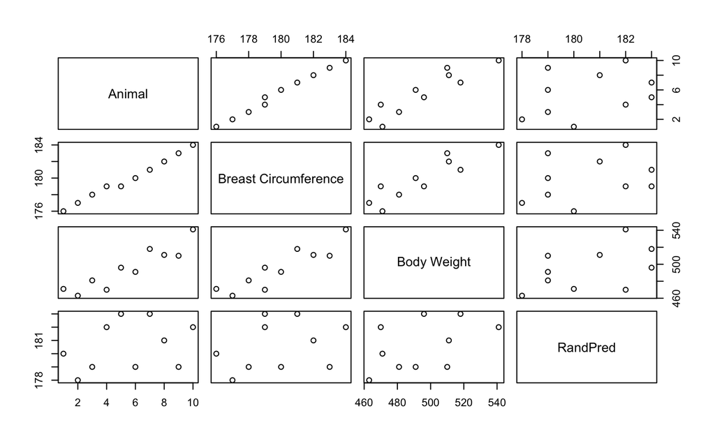

```r
pairs(tbl_data)
```

# Model Selection

Full model

```r
lm_bw_bc_rp <- lm(formula = `Body Weight` ~ `Breast Circumference` + RandPred,
                    data = tbl_data)
summary(lm_bw_bc_rp)
```

```
Call:
lm(formula = `Body Weight` ~ `Breast Circumference` + RandPred,
    data = tbl_data)

Residuals:
     Min       1Q   Median       3Q      Max
-21.9487  -2.0365   0.3772   6.7539   8.8617

Coefficients:
                        Estimate Std. Error t value Pr(>|t|)
(Intercept)            -1464.607    368.944  -3.970 0.005394 **
`Breast Circumference`     8.038      1.408   5.708 0.000729 ***
RandPred                   2.845      1.993   1.427 0.196541
---
Signif. codes:  0 ‘***’ 0.001 ‘**’ 0.01 ‘*’ 0.05 ‘.’ 0.1 ‘ ’ 1

Residual standard error: 10.43 on 7 degrees of freedom
Multiple R-squared:  0.8632,    Adjusted R-squared:  0.8242
F-statistic: 22.09 on 2 and 7 DF,  p-value: 0.0009462
```

```r
library(dplyr)
tbl_ms_vc_olsrr <- tbl_data %>% rename(BW = `Body Weight`, BC = `Breast Circumference`)
lm_ms_vc_olsrr <- lm(BW ~ BC + RandPred, data = tbl_ms_vc_olsrr)
olsrr::ols_step_best_subset(lm_ms_vc_olsrr)
```

[output not shown]

Alternative

```r
MASS::stepAIC(lm_ms_vc_olsrr)
```

```
Start:  AIC=49.32
BW ~ BC + RandPred

           Df Sum of Sq    RSS    AIC
<none>                   760.9 49.320
- RandPred  1     221.5  982.4 49.874
- BC        1    3541.6 4302.5 64.644

Call:
lm(formula = BW ~ BC + RandPred, data = tbl_ms_vc_olsrr)

Coefficients:
(Intercept)           BC     RandPred
  -1464.607        8.038        2.845
```

# ANOVA

```r
aov_bw_bc_rp <- aov(formula = `Body Weight` ~ `Breast Circumference` + RandPred,
                    data = tbl_data)
(smry_aov_bw_bc_rp <- summary(aov_bw_bc_rp))
```

```
                       Df Sum Sq Mean Sq F value   Pr(>F)
`Breast Circumference`  1   4581    4581  42.143 0.000337 ***
RandPred                1    221     221   2.037 0.196541
Residuals               7    761     109
---
Signif. codes:  0 ‘***’ 0.001 ‘**’ 0.01 ‘*’ 0.05 ‘.’ 0.1 ‘ ’ 1
```

## Computation of Sum of Squares (`Sum Sq`)

The total sum of squares ($SSQ_T$) is computed by summing over the squared deviations of the observed body weights from the mean body weight. This is computed as

```r
n_mean_bw <- mean(tbl_data$`Body Weight`)
ssq_t <- sum((tbl_data$`Body Weight` - n_mean_bw)^2)
ssq_t
```

```
[1] 5563.6
```

This corresponds to the sum of all entries in the column `Sum Sq` in the ANOVA-Table shown above.

```r
sum(smry_aov_bw_bc_rp[[1]][, "Sum Sq"])
```

```
[1] 5563.6
```

### Residuals

The sum of squares of the residuals is the sum of the squared deviations of the observed body weights minus the fitted values of the regression model. This corresponds to

```r
ssq_r <- sum((tbl_data$`Body Weight` - fitted(aov_bw_bc_rp))^2)
ssq_r
```

```
[1] 760.9409
```

From the ANOVA table we get

```r
smry_aov_bw_bc_rp[[1]]["Residuals", "Sum Sq"]
```

```
[1] 760.9409
```

### Regression

The sum of squares that can be attributed to the regression model is computed by the sum of the squared deviations between the fitted values minus the mean body weight.

```r
ssq_m <- sum((fitted(aov_bw_bc_rp) - n_mean_bw)^2)
ssq_m
```

```
[1] 4802.659
```

This corresponds to the sum of the values in column `Sum Sq` for `Breast Circumference` and `RandPred`.

```r
smry_aov_bw_bc_rp[[1]]["`Breast Circumference`", "Sum Sq"] + smry_aov_bw_bc_rp[[1]]["RandPred", "Sum Sq"]
```

```
[1] 4802.659
```

The sum of squares for the predictor `Breast Circumference` is computed as the regression sum of squares in a model where only `Breast Circumference` is used as the only predictor.

```r
aov_bw_bc <- aov(formula = `Body Weight` ~ `Breast Circumference`, data = tbl_data)
smry_aov_bw_bc <- summary(aov_bw_bc)
ssq_b <- sum((fitted(aov_bw_bc) - n_mean_bw)^2)
ssq_b
```

```
[1] 4581.203
```

From the ANOVA table of the full model

```r
smry_aov_bw_bc_rp[[1]]["`Breast Circumference`", "Sum Sq"]
```

```
[1] 4581.203
```

The sum of squares for the predictor `Rand Pred` correspond to the difference between the regression sum of squares minus the sum of squares computed for `Breast Circumference` alone

```r
ssq_m - ssq_b
```

```
[1] 221.4565
```

From the ANOVA table, we get

```r
smry_aov_bw_bc_rp[[1]]["RandPred", "Sum Sq"]
```

```
[1] 221.4565
```

The computation of the sum of squares for the single predictor indicate that the order of the predictor matters. The order in which the sum of squares of the single predictors are computed is determined by the order of the predictor in the formula specified in the call to `aov()`. Hence the following call results in a different ANOVA table

```r
summary(aov(formula = `Body Weight` ~ RandPred + `Breast Circumference`, data = tbl_data))
```

```
                       Df Sum Sq Mean Sq F value   Pr(>F)
RandPred                1   1261    1261   11.60 0.011349 *
`Breast Circumference`  1   3542    3542   32.58 0.000729 ***
Residuals               7    761     109
---
Signif. codes:  0 ‘***’ 0.001 ‘**’ 0.01 ‘*’ 0.05 ‘.’ 0.1 ‘ ’ 1
```

Comparing the second version of the ANOVA table to the original one, shows that it is better to order the predictors according to their value in the `Sum Sq` column.

## Sire Variance Component

A column with the ID of the sire is added.

```r
tbl_ms_vc_sire <- tbl_data
tbl_ms_vc_sire$Sire <- c(rep(1,3), rep(2,3), rep(3,4))
tbl_ms_vc_sire
```

| Animal | Breast Circumference | Body Weight | RandPred | Sire |
| --- | --- | --- | --- | --- |
| 1 | 176 | 471 | 180 | 1 |
| 2 | 177 | 463 | 178 | 1 |
| 3 | 178 | 481 | 179 | 1 |
| 4 | 179 | 470 | 182 | 2 |
| 5 | 179 | 496 | 183 | 2 |
| 6 | 180 | 491 | 179 | 2 |
| 7 | 181 | 518 | 183 | 3 |
| 8 | 182 | 511 | 181 | 3 |
| 9 | 183 | 510 | 179 | 3 |
| 10 | 184 | 541 | 182 | 3 |

```r
NA
```

```r
tbl_ms_vc_sire$Sire <- as.factor(tbl_ms_vc_sire$Sire)
tbl_ms_vc_sire
```

| Animal | Breast Circumference | Body Weight | RandPred | Sire |
| --- | --- | --- | --- | --- |
| 1 | 176 | 471 | 180 | 1 |
| 2 | 177 | 463 | 178 | 1 |
| 3 | 178 | 481 | 179 | 1 |
| 4 | 179 | 470 | 182 | 2 |
| 5 | 179 | 496 | 183 | 2 |
| 6 | 180 | 491 | 179 | 2 |
| 7 | 181 | 518 | 183 | 3 |
| 8 | 182 | 511 | 181 | 3 |
| 9 | 183 | 510 | 179 | 3 |
| 10 | 184 | 541 | 182 | 3 |

```r
NA
```

To have a balanced dataset, we only use the first nine observations.

```r
tbl_ms_vc_sire <- tbl_ms_vc_sire[1:9,]
tbl_ms_vc_sire
```

| Animal | Breast Circumference | Body Weight | RandPred | Sire |
| --- | --- | --- | --- | --- |
| 1 | 176 | 471 | 180 | 1 |
| 2 | 177 | 463 | 178 | 1 |
| 3 | 178 | 481 | 179 | 1 |
| 4 | 179 | 470 | 182 | 2 |
| 5 | 179 | 496 | 183 | 2 |
| 6 | 180 | 491 | 179 | 2 |
| 7 | 181 | 518 | 183 | 3 |
| 8 | 182 | 511 | 181 | 3 |
| 9 | 183 | 510 | 179 | 3 |

Determine sire variance component using `aov()`.

```r
aov_ms_vc_sire <- aov(`Body Weight` ~ Sire, data = tbl_ms_vc_sire)
smry_aov_ms_vc_sire <- summary(aov_ms_vc_sire)
smry_aov_ms_vc_sire
```

```
            Df Sum Sq Mean Sq F value  Pr(>F)
Sire         2 2651.6  1325.8   13.68 0.00581 **
Residuals    6  581.3    96.9
---
Signif. codes:  0 ‘***’ 0.001 ‘**’ 0.01 ‘*’ 0.05 ‘.’ 0.1 ‘ ’ 1
```

```r
n_sigma_s2 <- (smry_aov_ms_vc_sire[[1]]["Sire", "Mean Sq"] - smry_aov_ms_vc_sire[[1]]["Residuals", "Mean Sq"]) / 3
n_sigma_s2
```

```
[1] 409.6296
```

REML

```r
lmer_ms_vc_sire <- lme4::lmer(`Body Weight` ~ (1|Sire), data = tbl_ms_vc_sire)
summary(lmer_ms_vc_sire)
```

```
Linear mixed model fit by REML ['lmerMod']
Formula: `Body Weight` ~ (1 | Sire)
   Data: tbl_ms_vc_sire

REML criterion at convergence: 66.7

Scaled residuals:
     Min       1Q   Median       3Q      Max
-1.62462 -0.20467 -0.03325  0.67790  1.01679

Random effects:
 Groups   Name        Variance Std.Dev.
 Sire     (Intercept) 409.63   20.239
 Residual              96.89    9.843
Number of obs: 9, groups:  Sire, 3

Fixed effects:
            Estimate Std. Error t value
(Intercept)   490.11      12.14   40.38
```